# Macro simulations

**NOTE**: The present notebook is coded in R. It relies heavily on the [**tidyverse**](https://www.tidyverse.org/) ecosystem of packages. We load the tidyverse below as a prerequisite for the rest of the notebook - along with a few other libraries.

$\rightarrow$ Don’t forget that code flows **sequentially**. A random chunk may not work if the previous have have not been executed.

```r
library(tidyverse)   # Package for data wrangling
library(readxl)      # Package to import MS Excel files
library(latex2exp)   # Package for LaTeX expressions
library(quantmod)    # Package for stock data extraction
library(highcharter) # Package for reactive plots
library(patchwork)   # Package for plot layout
```

The content of the notebook is based on the [**Macro Simulation**](https://macrosimulation.org/) website and the [neoclassical case](https://macrosimulation.org/a_neoclassical_macro_model) in particular.

# 1 Context

Until now, we have seen a lot of theory, but limited simulations… This notebook is intended on providing some elements in this direction. And to show if the models achieve convergence - or not.

# 2 The model

## 2.1 Production & co.

We first start with a **Cobb-Douglas** production function:
$$Y=AK^aN^{1-a}, \quad a \in(0,1), \tag{1}$$
where $N$ is labour/employment/active population. Next, the real **wages**
$$w=(1-a)A(K/N)^a \tag{2}$$
This comes from the **labour demand** of profit-maximizing firms. Indeed, the profit is
$$\Pi(N)=AK^aN^{1-a}-wN-\text{other costs}, \tag{3}$$
hence the FOC is $\frac{\partial \Pi}{\partial N}=(1-a)A(K/N)^a-w=0$ *QED*.

Government expenditures are tied by: $G=T+B$, i.e., **taxes** plus **debt**. But the future value is $G^f=T^f-(1+r)B$ because the **interest** of the debt must be reimbursed (no default here!). Solving for $B$ gives

$$G+\frac{G^f}{1+r}=T+\frac{T^f}{1+r}. \tag{4}$$

Labor supply is given by
$$N = 1-b_1/w. \tag{5}$$

One way to come to this result is the following and stems from arbitrage with respect to leisure. We can assume that the agent in the economy has **utility**
$$U(C,N)= C+b \log(1-N),$$

where $1-N$ represents (properly normalized) the time dedicated to **leisure**. The parameter $b$ tunes how much leisure matters for the agent. At the same time, the agent needs to work to consume: $C=wN$. There are thus two competing effects: increase work to consume more or decrease work to spend more time on leisure. The logarithmic function is key to obtaining the desired form.

The FOC with respect to *N* (replacing $C$ in the above expression) is thus
$$\frac{\partial U}{\partial N}=w-\frac{b}{1-N}=0 \quad \Leftrightarrow \quad w(1-N)=b \quad \Leftrightarrow \quad N=1-b/w$$

## 2.2 Consumption

In fact the **true utility** is more complex:
$$U(C)=\log(C+b_1\log(1-N))+b_2\log(C^f),$$
where $C^f$ is *future* consumption (expected and treated as exogenous), which is subject to a budget constraint involving future output. The current constraint is
$$C=Y-T-S,$$
i.e., what is consumed is what is produced, minus taxes minus what is saved at rate $r$. The future version is
$$C^f=Y^f-T^f+(1+r)S.$$
Solving for $S$,

$$C^f=Y^f-T^f+(1+r)(Y-T-C),$$
where we can replace **taxes** by **government spending** thanks to Equation 4:
$$C^f=Y^f-G^f+(1+r)(Y-G-C),$$

Hence the utility becomes

$$U(C,N)=\log(C+b_1\log(1-N))+b_2\log(Y^f-G^f+(1+r)(Y-G-C))$$

Then,

$$\frac{\partial U}{\partial C}=\frac{1}{C+b_1\log(1-N)}-\frac{b_2(1+r)}{Y^f-G^f+(1+r)(Y-G-C)},$$
so the FOC with respect to $C$ is

$$C^f=b_2(1+r)(C+b_1\log(1-N)) \quad \Leftrightarrow \quad C=\frac{C^f}{b_2(1+r)}-b_1\log(1-N) \tag{6}$$

$$\frac{\partial U}{\partial N}=\frac{-b_1}{(1-N)(C+b_1\log(1-N))}+\frac{b_2(1+r)w}{C^f}$$
where we recognize a similar term from Equation 6, which gives

$$C=w\frac{(1-N)(C+b_1\log(1-N))}{b_1}-b_1\log(1-N)$$

and rearranging
$$C+b_1\log(1-N)=w\frac{(1-N)(C+b_1\log(1-N))}{b_1} \Leftrightarrow b_1/w = (1-N)$$
*QED* (same form as before!).

# 3 The code

In fact, the original code has some unnecessary parts if we are only interested in production or consumption.  
Below, we keep only the required rows.

## 3.1 Initializing variables

```r
S <- 5            # Number of scenarios (including baseline)
nb_sim <- 20      # Number of simulations

# Create and parameterise exogenous variables/parameters that will be shifted
G0 <- vector(length=S) # government expenditures
A <- vector(length=S)  # productivity
Yf <- vector(length=S) # expected future income
b1 <- vector(length=S) # household preference for leisure
G0[]=1
A[]=2
Yf[]=1
b1[]=0.4
```

```r
# Set parameter values for different scenarios
G0[2] <- 2   # scenario 3: fiscal expansion
A[3] <- 3.5  # scenario 4: productivity boost
Yf[4] <- 0.2 # scenario 5: lower expected future income
b1[5] <- 0.8 # scenario 6: increased preference for leisure

#Set constant parameter values
a <- 0.3   # Capital elasticity of output
b2 <- 0.9  # discount rate
b3 <- 0.6  # household preference for money
K <- 5     # Exogenous capital stock
pe <- 0.02 # Expected rate of inflation
Gf <- 1    # Future government spending

# Initialise endogenous variables at arbitrary positive value
w <- matrix(1, ncol = S, nrow = nb_sim)
C = I = Y = r = N = P = w
```

## 3.2 Running the loop

```r
#Solve this system numerically through 1000 iterations based on the initialization
for (i in 1:S){
  for (t in 2:nb_sim){
    #Model equations
    Y[t, i] <- A[i]*(K^a)*N[t-1, i]^(1-a)                 #(1) Cobb-Douglass production function
    w[t, i] <- A[i]*(1-a)*(K^a)*N[t-1, i]^(-a)            #(2) Labor demand
    N[t, i] <- 1 - (b1[i])/w[t-1, i]                      #(3) Labor supply
    #(4) Consumption demand
    C[t, i] <- (1/(1+b2+b3))*(Y[t-1, i] - G0[i] + (Yf[i]-Gf)/(1+r[t-1, i]) -b1[i]*(b2+b3)*log(b1[i]/w[t-1, i]))
    r[t, i] <- (I[t-1, i]^(a-1))*a*A[i]*N[t,i]^(1-a)      #(5) Investment demand, solved for r
    I[t, i] <- Y[t, i] - C[t,i] - G0[i]                   #(6) Goods market equilibrium condition, solved for I
  }
}
```

Let’s plot the result!

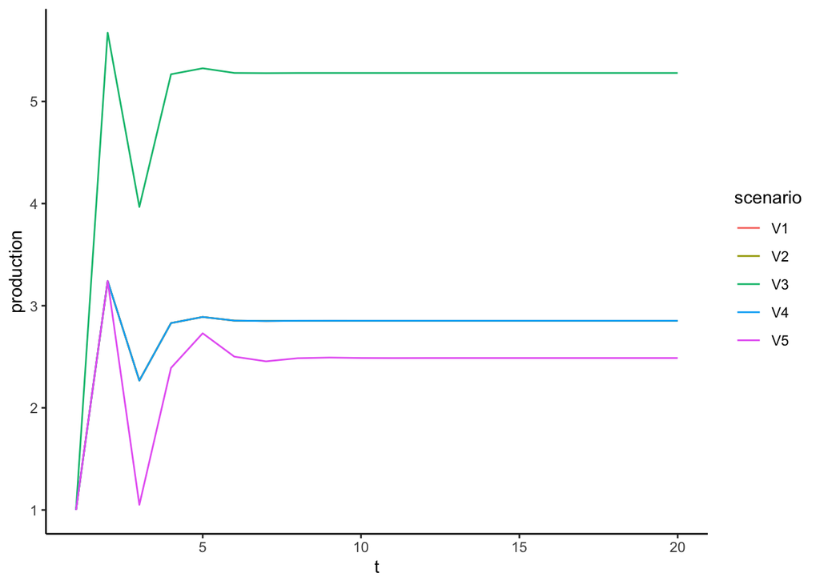

```r
bind_cols(t = 1:nb_sim, as_tibble(Y)) |>
  pivot_longer(-t, names_to = "scenario", values_to = "production") |>
  ggplot(aes(x = t, y = production, color = scenario)) + geom_line() +
  theme_classic() + theme(legend.position.inside = c(0.5,0.5))
```

Some scenarios are redundant (initial choices have no impact).

Let’s have a look at **consumption**…

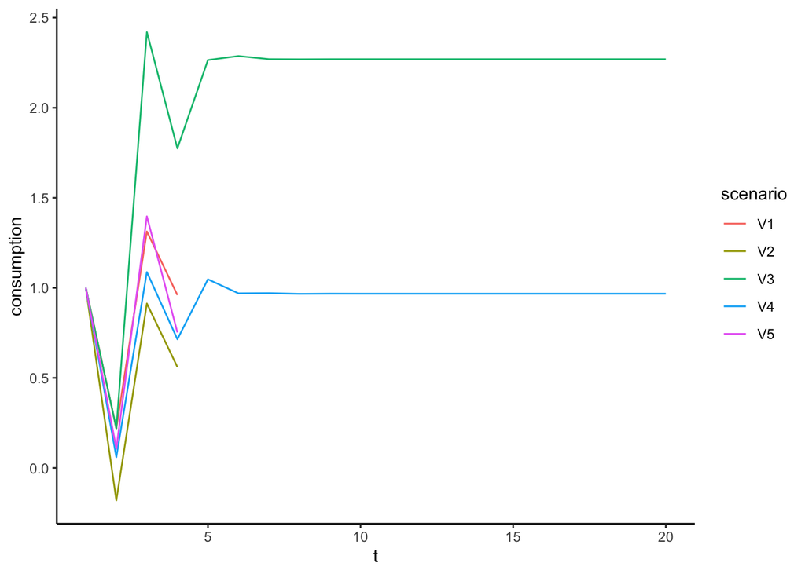

```r
bind_cols(t = 1:nb_sim, as_tibble(C)) |>
  pivot_longer(-t, names_to = "scenario", values_to = "consumption") |>
  ggplot(aes(x = t, y = consumption, color = scenario)) + geom_line() +
  theme_classic() + theme(legend.position.inside = c(0.5,0.5))
```

What if we add a little noise on the production side? With small shocks to **labor supply**.

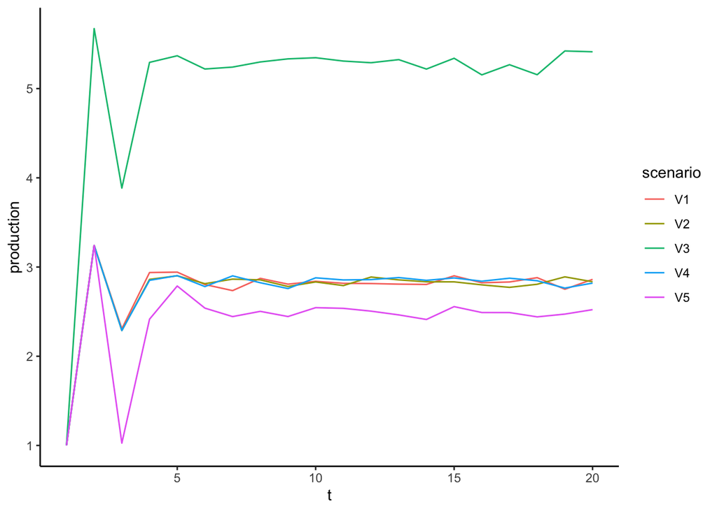

```r
#Solve this system numerically through 1000 iterations based on the initialization
for (i in 1:S){
  for (t in 2:nb_sim){
    #Model equations
    Y[t, i] <- A[i]*(K^a)*N[t-1, i]^(1-a)                  # (1) Cobb-Douglass production function
    w[t, i] <- A[i]*(1-a)*(K^a)*N[t-1, i]^(-a)             # (2) Labor demand
    N[t, i] <- 1 - (b1[i])/w[t-1, i] + rnorm(1, sd = 0.02) # (3) Labor supply
  }
}
bind_cols(t = 1:nb_sim, as_tibble(Y)) |>
  pivot_longer(-t, names_to = "scenario", values_to = "production") |>
  ggplot(aes(x = t, y = production, color = scenario)) + geom_line() +
  theme_classic() + theme(legend.position.inside = c(0.5,0.5))
```

Ok, so we still have **convergence** (mostly).  
What if the shocks are ten times larger?

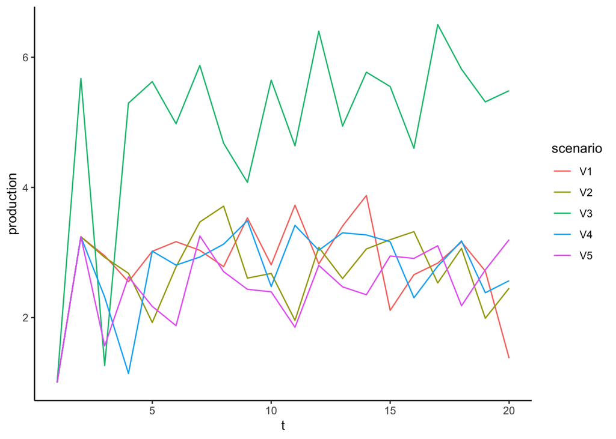

```r
#Solve this system numerically through 1000 iterations based on the initialization
set.seed(42)
for (i in 1:S){
  for (t in 2:nb_sim){
    #Model equations
    Y[t, i] <- A[i]*(K^a)*N[t-1, i]^(1-a)                  # (1) Cobb-Douglass production function
    w[t, i] <- A[i]*(1-a)*(K^a)*N[t-1, i]^(-a)             # (2) Labor demand
    N[t, i] <- 1 - (b1[i])/w[t-1, i] + rnorm(1, sd = 0.2)  # (3) Labor supply
  }
}
bind_cols(t = 1:nb_sim, as_tibble(Y)) |>
  pivot_longer(-t, names_to = "scenario", values_to = "production") |>
  ggplot(aes(x = t, y = production, color = scenario)) + geom_line() +
  theme_classic() + theme(legend.position.inside = c(0.5,0.5))
```

Rocky, but still relatively consistent.